# Introduction

Now it so happens that we want to calculated the distance between two points. That is, the shortest route distance. This form of distance calculation is the simplest form of [route analysis](https://desktop.arcgis.com/en/arcmap/latest/extensions/network-analyst/route.htm). Route analysis is part of the larger [network form of analyses](https://gisgeography.com/network-analysis/). Within route analysis, one can engage to find out the shortest, fastest or even the most scenic route. It all depends on the impedance you are trying to overcome.

Today we shall endeavour to calculate a route analysis of the shortest distance between two points. In a previous exercise we took a long stroll along the beach by working with two famous tourist points. One of them was the Vasco da Gama Pillar in Malindi. Today we shall work with a different point, Malindi International Airport. Therefore, we shall endeavour to find out the shortest distance between the two points of interest.

As always, give a geographer a point on the earth's surface and he shall make his way around. Here are the coordinates for our two chosen places for this exercise.

| Name | Longitude | Latitude | | ---- | --------- | -------- | | Vasco da Gama Pillar | 40.1276701 | -3.2236304 | | Malindi International Airport | 39.9599064 | -3.2311121 |

In order to conduct geospatial experiments with the above data, we have to convert it to a geodataframe. As always, the necessary tools of the trade have to be loaded.

```python
import pandas as pd
import geopandas as gpd
```

```python
# Create dataframe for our places of interest
df = pd.DataFrame({
    'Name': ['Vasco da Gama', 'Malindi International Airport'],
    'Longitudes': [40.1276701, 39.9599064], # don't confuse with latitudes like inserting long lat format!
    'Latitudes': [-3.2236304, -3.2311121]}
)
```

```python
# Convert to geodataframe
coast_gdf = gpd.GeoDataFrame(df,
                             geometry=gpd.points_from_xy(df.Longitudes, df.Latitudes)
                            )
```

```python
# Read the geodataframe table
coast_gdf.head()
```

|  | Name | Longitudes | Latitudes | geometry |
| --- | --- | --- | --- | --- |
| 0 | Vasco da Gama | 40.127670 | -3.223630 | POINT (40.12767 -3.22363) |
| 1 | Malindi International Airport | 39.959906 | -3.231112 | POINT (39.95991 -3.23111) |

There we go!

Now, we would like to calculate the shortest route distance between the two above points and extract the route. Our source of the route, say the road, will be from an Open Streetmap (OSM) network. The osmnx package is the tool which enables us to extract network components, such as edges, nodes and polygons from our OSM. Now if you are new to GIS, the term edges and nodes may confuse you. But don't let it scare you, you can think of edges as any line that connects between two points. Unlike in maths where you think it as the line between two triangle corners, in GIS it is more like a road connecting from point A to B. Nodes are simply the points that mark the beginning or ending points of a line, which we have called here an *edge*. Example, from junction A to junction B. A picture is worth a thousand words, so here you go...

[figure not shown]

Now therefore lets load the [osmnx package](https://osmnx.readthedocs.io/en/stable/).

```python
# load the osmnx package into Jupyter
import osmnx as ox
```

We want to extract the OSM data within the limits of our two points. Of course you don't want so much a large area that may increase computing time, or divert focus from your area. You can do so by specifying the upper and lower bounds (upper north, lower south, easternmost east and westernmost west) coordinate values, but there is an easier way that eliminates typing these values manually, and it involves creating these bounds for our geodataframe.

```python
# Calculate the bounds of our geodataframe
coast_gdf.total_bounds
```

```
array([39.9599064, -3.2311121, 40.1276701, -3.2236304])
```

The tool `graph_from_bbox` which we shall use to extract the OSM data requires inserting the [above coordinates in a particular order](https://osmnx.readthedocs.io/en/stable/osmnx.html?highlight=graph_from_box#osmnx.graph.graph_from_bbox)--that is, north, south, east, west. Therefore we shall proceed to do so as prescribed.

```python
# Derive osm graph from bounding box
area_osm_graph = ox.graph_from_bbox(-3.2200000, -3.2300000, 40.1200000, 39.9500000,
                                  network_type="drive",
                                  simplify=True,
                                  )
```

Now, after we have defined the area in which we shall extract our OSM data, we need to plot it. The tool to plot our OSM network is `plot_graph`.

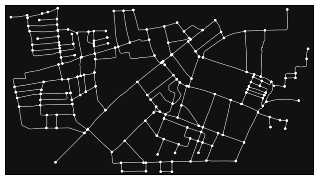

```
(<Figure size 800x800 with 1 Axes>, <AxesSubplot: >)
```

```python
# Project the osm graph
ox.plot_graph(area_osm_graph)
```

Now, in order to plot the roads alone and the points along the road alone, as in, separately or each appearing distinctly on the map, we have to extract them according to their type. What we mean is that we have to extract the edges and nodes from the above graph which has collectively put them together.

Let's start with edges first.

```python
# Retrieve edges
edges = ox.graph_to_gdfs(area_osm_graph, nodes=False, edges=True)
edges.head()
```

| u | v | key | osmid | ref | name | highway | oneway | reversed | length | geometry |
| --- | --- | --- | --- | --- | --- | --- | --- | --- | --- | --- |
| 308935402 | 6360256831 | 0 | 51728703 | B8 | Malindi Road | primary | False | False | 201.422 | LINESTRING (40.10960 -3.22450, 40.11080 -3.223... |
|  | 3759325238 | 0 | 51728703 | B8 | Malindi Road | primary | False | True | 282.354 | LINESTRING (40.10960 -3.22450, 40.10892 -3.225... |
|  | 2286758026 | 0 | 219527389 | NaN | NaN | residential | False | False | 109.363 | LINESTRING (40.10960 -3.22450, 40.10973 -3.224... |
| 308935403 | 6360256828 | 0 | 51728703 | B8 | Malindi Road | primary | False | False | 10.657 | LINESTRING (40.11107 -3.22334, 40.11114 -3.22328) |
|  | 6360256831 | 0 | 51728703 | B8 | Malindi Road | primary | False | True | 7.015 | LINESTRING (40.11107 -3.22334, 40.11102 -3.22338) |

Now, let's retrieve the nodes as well.

```python
# Retrieve nodes
nodes = ox.graph_to_gdfs(area_osm_graph, nodes=True, edges=False)
nodes.head()
```

| osmid | y | x | street_count | geometry |
| --- | --- | --- | --- | --- |
| 308935402 | -3.224505 | 40.109595 | 3 | POINT (40.10960 -3.22450) |
| 308935403 | -3.223338 | 40.111065 | 3 | POINT (40.11107 -3.22334) |
| 308938549 | -3.222092 | 40.112633 | 3 | POINT (40.11263 -3.22209) |
| 308938628 | -3.224541 | 40.112135 | 3 | POINT (40.11214 -3.22454) |
| 308938635 | -3.225818 | 40.115815 | 3 | POINT (40.11582 -3.22582) |

We are now getting closer to conducting our route analysis. How we wish some of these things were as easy as pushing a button. Clearly, they are not! A route has a start and end point. In order for [python to do the route analysis](https://autogis-site.readthedocs.io/en/latest/lessons/lesson-6/network-analysis.html) under the hood, it also needs these same crucial two points to do its calculation and give us the shortest route from a labyrinth of edges and nodes, roads and junctions, paths and corners...

```python
# The starting point
origin = (
    ox.geocode_to_gdf('N2628519930', by_osmid=True)  # fetch geolocation
    .to_crs(edges.crs)  # transform to UTM
    .at[0, "geometry"]  # pick geometry of first row
    .centroid  # use the centre point
)
```

```python
# the end point
destination = (
    ox.geocode_to_gdf("W239289174", by_osmid=True)
    .to_crs(edges.crs)
    .at[0, "geometry"]
    .centroid
)
```

There is still another problem though. What if our nodes, the places of interest, are not along the edges? Yes, it is very much possible and if a node is not a long the edge, osmnx will not locate and thus will not carry out the route analysis. So what do we do? The function `nearest_nodes` will find the nearest nodes to our points, from within and part our graph network--the `area_osm_graph`--thus enabling the route analysis possible because they are on line.

```python
# find the nearest node to our start point
origin_node_id = ox.nearest_nodes(area_osm_graph, origin.x, origin.y)
origin_node_id
```

```
2286757975
```

```python
# find the nearest node to our end point
destination_node_id = ox.nearest_nodes(area_osm_graph, destination.x, destination.y)
destination_node_id
```

```
3759325223
```

```python
nodes.columns.values
```

```
array(['y', 'x', 'street_count', 'geometry'], dtype=object)
```

```python
# find if one of the osmids exists
index = nodes.index

for i in index:
    if i == 2286757975:
        print("True, that osm id exists")
        print(nodes.loc[[i]])
else:
    print("No such osm id exists")
```

```
True, that osm id exists
                   y          x  street_count                   geometry
osmid
2286757975 -3.222533  40.119786             3  POINT (40.11979 -3.22253)
No such osm id exists
```

Ok for sure the osm id for origin_node exists. So, functions can be hard to wrap our head around sometimes, so let's attempt to break it down to help those wishful beginners who want to be pros. If wishes, were horses, beggars should ride on them. Don't you think?

Let's go line by line

```
# find if one of the osmids exists
index = nodes.index
```

This should be pretty straightforward. Assigns the indexes of the nodes to the `index` object.

```
for i in index:
```

Very simple, iterates for every index, given the pseudonym `i` here --within the list of indexes in the object - `index`.

```
if i == 2286757975:
         print("True, that osm id exists")
         print(nodes.loc[[i]])
```

Now let's go the above suite line by line. The `if` statement says that for any index christened `i` within the `index` list is equal to the value `2286757975`, then do this: print ""True, that osm id exists" and then show the row using:

```
print(nodes.loc[[i]])
```

The `loc` function is actually used in accessing columns like in .loc['index'], and show the rows falling *within* that column. But when we use the `[[]]` we get more specific. We are actually telling loc to show the row where that value exists.

How about the osm id for our destination, does it exist?

```python
# Find if the osm id for destination exists -- 3759325223
for i in index:
    if i == 3759325223:
        print("True, that osm id exists")
        print(nodes.loc[[i]])
else:
    print("No such osm id exists")
```

```
True, that osm id exists
                   y          x  street_count                   geometry
osmid
3759325223 -3.225462  40.102424             3  POINT (40.10242 -3.22546)
No such osm id exists
```

Now time for the big thing, calculating the shortest route between our origin and destination nodes.

```python
# Find the shortest path between origin and destination
route = ox.shortest_path(area_osm_graph, origin_node_id, destination_node_id) # The function shortest_path calculates the shortest path
route
```

```
[2286757975,
 6354461008,
 9955514833,
 9955514568,
 9955514255,
 6360255777,
 6360255780,
 6360161111,
 1315243444,
 2286757997,
 6360256820,
 308938639,
 4561905038,
 308938549,
 6360256813,
 6360256809,
 6360256828,
 308935403,
 6360646744,
 3759325170,
 3759325171,
 2082264348,
 6354717897,
 3759325183,
 3759325198,
 3759325199,
 3759325205,
 3759325206,
 6354753161,
 6360646754,
 6354753165,
 3759325223]
```

Time to plot it using the `plot_graph_route` function.

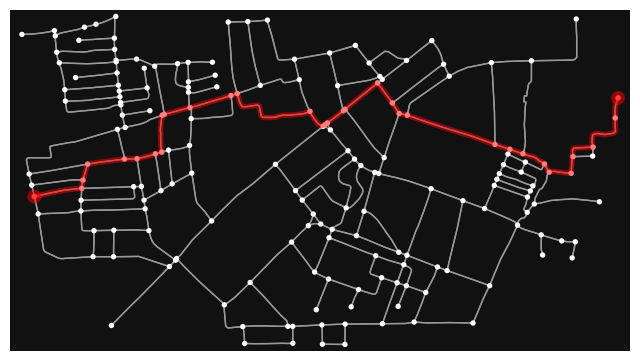

```python
# Plot the shortest path
fig, ax = ox.plot_graph_route(area_osm_graph, route)
```

The osmnx package does a good job of fixing node to node until we get a route. However, to use our `route` in other applications, we need to save it to a variable with a compatible format. How? Simple, we create a LineString. The tool for this job is the `shapely` package. You may think of passing the `route` object to a shapely.geometry.LineString function and go to sleep, but frankly, you are wrong. We did it and we got slapped with another error :(. Since our `nodes` object is a geometry file, we shall collect the route values, yes those long numbers and chose those that correspond to the `nodes` file. We are thinking of a typical `join` function.

```python
nodes.head()
```

| osmid | y | x | street_count | geometry |
| --- | --- | --- | --- | --- |
| 308935402 | -3.224505 | 40.109595 | 3 | POINT (40.10960 -3.22450) |
| 308935403 | -3.223338 | 40.111065 | 3 | POINT (40.11107 -3.22334) |
| 308938549 | -3.222092 | 40.112633 | 3 | POINT (40.11263 -3.22209) |
| 308938628 | -3.224541 | 40.112135 | 3 | POINT (40.11214 -3.22454) |
| 308938635 | -3.225818 | 40.115815 | 3 | POINT (40.11582 -3.22582) |

On second thought. Perhaps not. We will use the `loc` function as used in a similar exercise [here](https://autogis-site.readthedocs.io/en/latest/lessons/lesson-6/network-analysis.html).

```python
# Get the nodes along the shortest path that also exist in the route geodataframe
route_nodes = nodes.loc[route]
route_nodes
```

| osmid | y | x | street_count | geometry |
| --- | --- | --- | --- | --- |
| 2286757975 | -3.222533 | 40.119786 | 3 | POINT (40.11979 -3.22253) |
| 6354461008 | -3.223128 | 40.119702 | 3 | POINT (40.11970 -3.22313) |
| 9955514833 | -3.223994 | 40.119041 | 3 | POINT (40.11904 -3.22399) |
| 9955514568 | -3.224277 | 40.118445 | 3 | POINT (40.11845 -3.22428) |
| 9955514255 | -3.224770 | 40.118389 | 3 | POINT (40.11839 -3.22477) |
| 6360255777 | -3.224739 | 40.117737 | 3 | POINT (40.11774 -3.22474) |
| 6360255780 | -3.224495 | 40.117597 | 3 | POINT (40.11760 -3.22450) |
| 6360161111 | -3.224190 | 40.116957 | 3 | POINT (40.11696 -3.22419) |
| 1315243444 | -3.224061 | 40.116569 | 3 | POINT (40.11657 -3.22406) |
| 2286757997 | -3.223916 | 40.116124 | 3 | POINT (40.11612 -3.22392) |
| 6360256820 | -3.223046 | 40.113515 | 3 | POINT (40.11352 -3.22305) |
| 308938639 | -3.222997 | 40.113275 | 3 | POINT (40.11328 -3.22300) |
| 4561905038 | -3.222684 | 40.113073 | 3 | POINT (40.11307 -3.22268) |
| 308938549 | -3.222092 | 40.112633 | 3 | POINT (40.11263 -3.22209) |
| 6360256813 | -3.222870 | 40.111668 | 3 | POINT (40.11167 -3.22287) |
| 6360256809 | -3.222914 | 40.111615 | 3 | POINT (40.11162 -3.22291) |
| 6360256828 | -3.223277 | 40.111139 | 3 | POINT (40.11114 -3.22328) |
| 308935403 | -3.223338 | 40.111065 | 3 | POINT (40.11107 -3.22334) |
| 6360646744 | -3.222934 | 40.110623 | 3 | POINT (40.11062 -3.22293) |
| 3759325170 | -3.222405 | 40.108461 | 4 | POINT (40.10846 -3.22241) |
| 3759325171 | -3.222464 | 40.108273 | 3 | POINT (40.10827 -3.22246) |
| 2082264348 | -3.222821 | 40.107054 | 4 | POINT (40.10705 -3.22282) |
| 6354717897 | -3.223021 | 40.106289 | 3 | POINT (40.10629 -3.22302) |
| 3759325183 | -3.223048 | 40.106231 | 3 | POINT (40.10623 -3.22305) |
| 3759325198 | -3.224143 | 40.106214 | 3 | POINT (40.10621 -3.22414) |
| 3759325199 | -3.224195 | 40.106024 | 3 | POINT (40.10602 -3.22419) |
| 3759325205 | -3.224338 | 40.105480 | 3 | POINT (40.10548 -3.22434) |
| 3759325206 | -3.224349 | 40.105107 | 3 | POINT (40.10511 -3.22435) |
| 6354753161 | -3.224501 | 40.104009 | 3 | POINT (40.10401 -3.22450) |
| 6360646754 | -3.224976 | 40.103872 | 3 | POINT (40.10387 -3.22498) |
| 6354753165 | -3.225221 | 40.103835 | 4 | POINT (40.10384 -3.22522) |
| 3759325223 | -3.225462 | 40.102424 | 3 | POINT (40.10242 -3.22546) |

Let's do a quick check to see if our origin and destination ideas are part of the `route_nodes` geodataframe we have created. This is the geodataframe that we shall convert to a LineString.

Okay the column name `osmid` is missing but it exists in the route_name geodataframe. Just have a quick glimpse one paragraph up. So it must be serving as the index then. We will simply crosscheck if our origin and destination ids exist by repeating the same loop we had done earlier when confirming their presence in the `nodes` file.

```python
for i in route_nodes.index:
    if i == 2286757975 or i == 3759325223:
        print(f"\nOSM id {i} exists.")
```

```
OSM id 2286757975 exists.

OSM id 3759325223 exists.
```

Now it's time to create a linestring from the nodes in our shortest path --the `route_nodes` object. We shall do so using the `shapely.geometry` module.

```python
# Import the geometry module from the shapely package
from shapely import geometry as gm
```

```python
# Create a geometry for the shortest path
route_line = gm.LineString(
    list(route_nodes.geometry.values)
)
route_line
```

[output not shown]

```python
# Check out the values in the route_nodes geometry
route_nodes.geometry
```

```
osmid
2286757975    POINT (40.11979 -3.22253)
6354461008    POINT (40.11970 -3.22313)
9955514833    POINT (40.11904 -3.22399)
9955514568    POINT (40.11845 -3.22428)
9955514255    POINT (40.11839 -3.22477)
6360255777    POINT (40.11774 -3.22474)
6360255780    POINT (40.11760 -3.22450)
6360161111    POINT (40.11696 -3.22419)
1315243444    POINT (40.11657 -3.22406)
2286757997    POINT (40.11612 -3.22392)
6360256820    POINT (40.11352 -3.22305)
308938639     POINT (40.11328 -3.22300)
4561905038    POINT (40.11307 -3.22268)
308938549     POINT (40.11263 -3.22209)
```

[output cut: 19 more lines]

Finally, let's create a table with a list of all the coordinates and OSM ids from which we shall calculate the length of the route.

```python
# Extract useful data from the geodatafram of route
route_geom = gpd.GeoDataFrame(
    {
        "geometry": [route_line],
        "osm_nodes": [route],
    },
    crs=edges.crs
)

route_geom
```

|  | geometry | osm_nodes |
| --- | --- | --- |
| 0 | LINESTRING (40.11979 -3.22253, 40.11970 -3.223... | [2286757975, 6354461008, 9955514833, 995551456... |

To calculate the length of the route, it is best if our data is in a local Coordinate Reference System (CRS) which is in metres or other spatial units. It is bad practice to calculate length or area of a spatial feature using the global CRS, such as EPSG:4326 because the measurement units are in degrees.

```python
# Check CRS
route_geom.crs
```

```
<Geographic 2D CRS: EPSG:4326>
Name: WGS 84
Axis Info [ellipsoidal]:
- Lat[north]: Geodetic latitude (degree)
- Lon[east]: Geodetic longitude (degree)
Area of Use:
- name: World.
- bounds: (-180.0, -90.0, 180.0, 90.0)
Datum: World Geodetic System 1984 ensemble
- Ellipsoid: WGS 84
- Prime Meridian: Greenwich
```

```python
# Convert the route_geom crs to EPSG:32737
route_geom = route_geom.to_crs("EPSG:32737")
route_geom.crs
```

```
<Derived Projected CRS: EPSG:32737>
Name: WGS 84 / UTM zone 37S
Axis Info [cartesian]:
- E[east]: Easting (metre)
- N[north]: Northing (metre)
Area of Use:
- name: Between 36°E and 42°E, southern hemisphere between 80°S and equator, onshore and offshore. Kenya. Mozambique. Tanzania.
- bounds: (36.0, -80.0, 42.0, 0.0)
Coordinate Operation:
- name: UTM zone 37S
- method: Transverse Mercator
Datum: World Geodetic System 1984 ensemble
- Ellipsoid: WGS 84
- Prime Meridian: Greenwich
```

To bring this to a close, (we promise!) we shall use the `length` method to calculate the length of our spatial feature, which will be in metres.

```python
# Calculate the route length
route_geom["length_m"] = route_geom.length

route_geom.head()
```

|  | geometry | osm_nodes | length_m |
| --- | --- | --- | --- |
| 0 | LINESTRING (624416.397 9643741.180, 624406.935... | [2286757975, 6354461008, 9955514833, 995551456... | 2455.409494 |

Just one more tiny bit, convert the metres to kilometres for stubborn spatial scientists who prefer a more conveninent value, like you!

```python
# Create function to convert row column values to km
def convert_m_km(geodataframe, column_name):
    return geodataframe.assign(length_km= lambda x: x.length_m / 1000)
```

```
km = row_column / 1000
```

We have just minimized what would have been two lines into one using the [lambda function](https://sparkbyexamples.com/pandas/pandas-apply-with-lambda-examples/).

```python
# Implement the function with your route attributes
convert_m_km(route_geom, route_geom['length_m'])
```

|  | geometry | osm_nodes | length_m | length_km |
| --- | --- | --- | --- | --- |
| 0 | LINESTRING (624416.397 9643741.180, 624406.935... | [2286757975, 6354461008, 9955514833, 995551456... | 2455.409494 | 2.455409 |

```python
import contextily as cx
```

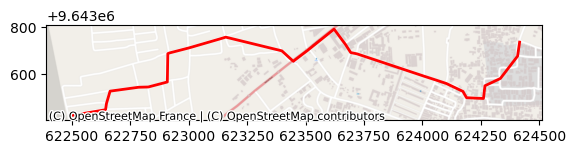

```python
# Draw route on top of basemap
import contextily as cx

ax1 = route_geom.plot(linewidth=2,
                    color='red'
                   )

cx.add_basemap(ax=ax1,
               crs=route_geom.crs.to_string(),
               source=cx.providers.OpenStreetMap.France
              )
```